# Actividad Final

## Online Sales

*El objetivo de la actividad es realizar el cargue de 2 Datasets, cruzar la información entre las bases y analizar las diferentes variables que lo componen.*

```python
#importar librerias
import pandas as pd
import numpy as np
import matplotlib.pyplot as plt
import seaborn as sns
```

```python
#carga datasets
df = pd.read_csv('Orders.csv')
df_1 = pd.read_csv('Details.csv')
```

```python
#Mostrar las primeras filas
print('Primeros registros del Dataframe Orders:')
df.head()
```

```
Primeros registros del Dataframe Orders:
```

|  | Order ID | Order Date | CustomerName | State | City |
| --- | --- | --- | --- | --- | --- |
| 0 | B-26055 | 10-03-2018 | Harivansh | Uttar Pradesh | Mathura |
| 1 | B-25993 | 03-02-2018 | Madhav | Delhi | Delhi |
| 2 | B-25973 | 24-01-2018 | Madan Mohan | Uttar Pradesh | Mathura |
| 3 | B-25923 | 27-12-2018 | Gopal | Maharashtra | Mumbai |
| 4 | B-25757 | 21-08-2018 | Vishakha | Madhya Pradesh | Indore |

```python
#valida tipo de datos
print('Tipos de datos del Dataframe Orders: ')
df.dtypes
```

```
Tipos de datos del Dataframe Orders:
```

```
Order ID        object
Order Date      object
CustomerName    object
State           object
City            object
dtype: object
```

```python
#Valida columnas
print('Columnas Dataframe Orders:')
df.columns
```

```
Columnas Dataframe Orders:
```

```
Index(['Order ID', 'Order Date', 'CustomerName', 'State', 'City'], dtype='object')
```

```python
#verifica cantidad de registros y columnas del Dataframe
print('Cantidad de registros y columnas del Dataframe Orders: ')
df.shape
```

```
Cantidad de registros y columnas del Dataframe Orders:
```

```
(500, 5)
```

```python
#Informacion general del Dataframe
print('Información general del Dataframe Orders: ')
df.info()
```

```
Información general del Dataframe Orders:
<class 'pandas.core.frame.DataFrame'>
RangeIndex: 500 entries, 0 to 499
Data columns (total 5 columns):
 #   Column        Non-Null Count  Dtype
---  ------        --------------  -----
 0   Order ID      500 non-null    object
 1   Order Date    500 non-null    object
 2   CustomerName  500 non-null    object
 3   State         500 non-null    object
 4   City          500 non-null    object
dtypes: object(5)
memory usage: 19.7+ KB
```

```python
#valida valores nulos en Dataframe
print('Valores nulos en Dataframe Orders:')
df.isnull().sum()
```

```
Valores nulos en Dataframe Orders:
```

```
Order ID        0
Order Date      0
CustomerName    0
State           0
City            0
dtype: int64
```

```python
#Mostrar las primeras filas
print('Primeros registros del Dataframe Details: ')
df_1.head()
```

```
Primeros registros del Dataframe Details:
```

|  | Order ID | Amount | Profit | Quantity | Category | Sub-Category | PaymentMode |
| --- | --- | --- | --- | --- | --- | --- | --- |
| 0 | B-25681 | 1096 | 658 | 7 | Electronics | Electronic Games | COD |
| 1 | B-26055 | 5729 | 64 | 14 | Furniture | Chairs | EMI |
| 2 | B-25955 | 2927 | 146 | 8 | Furniture | Bookcases | EMI |
| 3 | B-26093 | 2847 | 712 | 8 | Electronics | Printers | Credit Card |
| 4 | B-25602 | 2617 | 1151 | 4 | Electronics | Phones | Credit Card |

```python
#valida tipo de datos
print('Tipos de datos del Dataframe Details: ')
df_1.dtypes
```

```
Tipos de datos del Dataframe Details:
```

```
Order ID        object
Amount           int64
Profit           int64
Quantity         int64
Category        object
Sub-Category    object
PaymentMode     object
dtype: object
```

```python
#valida cantidad de registros y columnas
print('Cantidad de registros y columnas Dataframe Details:')
df_1.shape
```

```
Cantidad de registros y columnas Dataframe Details:
```

```
(1500, 7)
```

```python
#valida columnas
print('Columnas Dataframe Details:')
df_1.columns
```

```
Columnas Dataframe Details:
```

```
Index(['Order ID', 'Amount', 'Profit', 'Quantity', 'Category', 'Sub-Category',
       'PaymentMode'],
      dtype='object')
```

```python
#valida nulos
print('Nulos en Dataframe Details:')
df_1.isnull().sum()
```

```
Nulos en Dataframe Details:
```

```
Order ID        0
Amount          0
Profit          0
Quantity        0
Category        0
Sub-Category    0
PaymentMode     0
dtype: int64
```

```python
#Informacion general Dataframe
print('Información Dataframe Details:')
df_1.info()
```

```
Información Dataframe Details:
<class 'pandas.core.frame.DataFrame'>
RangeIndex: 1500 entries, 0 to 1499
Data columns (total 7 columns):
 #   Column        Non-Null Count  Dtype
---  ------        --------------  -----
 0   Order ID      1500 non-null   object
 1   Amount        1500 non-null   int64
 2   Profit        1500 non-null   int64
 3   Quantity      1500 non-null   int64
 4   Category      1500 non-null   object
 5   Sub-Category  1500 non-null   object
 6   PaymentMode   1500 non-null   object
dtypes: int64(3), object(4)
memory usage: 82.2+ KB
```

Se consolidan los Dataframes inicialmente cargados ("Orders" y "Details") utilizando el metodo merge por la variable "Order ID" (común en ambos Dataframes)

```python
#unir dataframes por la columna Order ID
df_final = pd.merge(df,df_1, on='Order ID', how='inner')

#visualiza primeros registros
print('Primeros registros del Dataframe unificado:')
df_final.head()
```

```
Primeros registros del Dataframe unificado:
```

|  | Order ID | Order Date | CustomerName | State | City | Amount | Profit | Quantity | Category | Sub-Category | PaymentMode |
| --- | --- | --- | --- | --- | --- | --- | --- | --- | --- | --- | --- |
| 0 | B-26055 | 10-03-2018 | Harivansh | Uttar Pradesh | Mathura | 5729 | 64 | 14 | Furniture | Chairs | EMI |
| 1 | B-26055 | 10-03-2018 | Harivansh | Uttar Pradesh | Mathura | 671 | 114 | 9 | Electronics | Phones | Credit Card |
| 2 | B-26055 | 10-03-2018 | Harivansh | Uttar Pradesh | Mathura | 443 | 11 | 1 | Clothing | Saree | COD |
| 3 | B-26055 | 10-03-2018 | Harivansh | Uttar Pradesh | Mathura | 57 | 7 | 2 | Clothing | Shirt | UPI |
| 4 | B-26055 | 10-03-2018 | Harivansh | Uttar Pradesh | Mathura | 227 | 48 | 5 | Clothing | Stole | COD |

Luego de consolidar los dataframe 'Orders' y 'Details' se logra visualizar el conjunto de datos con las columnas e información de ambos dataframes.

```python
#visualiza ultimos registros
print('Ultimos registros del Dataframe unificado:')
df_final.tail()
```

```
Ultimos registros del Dataframe unificado:
```

|  | Order ID | Order Date | CustomerName | State | City | Amount | Profit | Quantity | Category | Sub-Category | PaymentMode |
| --- | --- | --- | --- | --- | --- | --- | --- | --- | --- | --- | --- |
| 1495 | B-25742 | 03-08-2018 | Ashwin | Goa | Goa | 11 | -8 | 2 | Clothing | Skirt | UPI |
| 1496 | B-26088 | 26-03-2018 | Bhavna | Sikkim | Gangtok | 11 | 5 | 2 | Clothing | Hankerchief | UPI |
| 1497 | B-25707 | 01-07-2018 | Shivani | Maharashtra | Mumbai | 8 | -6 | 1 | Clothing | Stole | COD |
| 1498 | B-25758 | 22-08-2018 | Shubham | Himachal Pradesh | Simla | 8 | -2 | 1 | Clothing | Stole | COD |
| 1499 | B-26095 | 28-03-2018 | Monisha | Rajasthan | Jaipur | 6 | 1 | 1 | Clothing | Kurti | UPI |

```python
#valida tipos de dato
print('Tipos de datos Dataframe unificado:')
df_final.dtypes
```

```
Tipos de datos Dataframe unificado:
```

```
Order ID        object
Order Date      object
CustomerName    object
State           object
City            object
Amount           int64
Profit           int64
Quantity         int64
Category        object
Sub-Category    object
PaymentMode     object
dtype: object
```

```python
#valida informacion del dataframe
print('Información Dataframe unificado:')
df_final.info()
```

```
Información Dataframe unificado:
<class 'pandas.core.frame.DataFrame'>
RangeIndex: 1500 entries, 0 to 1499
Data columns (total 11 columns):
 #   Column        Non-Null Count  Dtype
---  ------        --------------  -----
 0   Order ID      1500 non-null   object
 1   Order Date    1500 non-null   object
 2   CustomerName  1500 non-null   object
 3   State         1500 non-null   object
 4   City          1500 non-null   object
 5   Amount        1500 non-null   int64
 6   Profit        1500 non-null   int64
 7   Quantity      1500 non-null   int64
 8   Category      1500 non-null   object
 9   Sub-Category  1500 non-null   object
 10  PaymentMode   1500 non-null   object
dtypes: int64(3), object(8)
memory usage: 129.0+ KB
```

```python
#valida nulos en dataframe
print('Nulos en Dataframe unificado:')
df_final.isnull().sum()
```

```
Nulos en Dataframe unificado:
```

```
Order ID        0
Order Date      0
CustomerName    0
State           0
City            0
Amount          0
Profit          0
Quantity        0
Category        0
Sub-Category    0
PaymentMode     0
dtype: int64
```

```python
#muestra estadisticas descriptivas
print('Estadisticas Dataframe unificado:')
df_final.describe()
```

```
Estadisticas Dataframe unificado:
```

|  | Amount | Profit | Quantity |
| --- | --- | --- | --- |
| count | 1500.000000 | 1500.00000 | 1500.000000 |
| mean | 291.847333 | 24.64200 | 3.743333 |
| std | 461.924620 | 168.55881 | 2.184942 |
| min | 4.000000 | -1981.00000 | 1.000000 |
| 25% | 47.750000 | -12.00000 | 2.000000 |
| 50% | 122.000000 | 8.00000 | 3.000000 |
| 75% | 326.250000 | 38.00000 | 5.000000 |
| max | 5729.000000 | 1864.00000 | 14.000000 |

```python
#total ventas por categoria
ventas_categoria = df_final.groupby('Category')['Amount'].sum()

print('Ventas por Categoria:')
print(ventas_categoria)
```

```
Ventas por Categoria:
Category
Clothing       144323
Electronics    166267
Furniture      127181
Name: Amount, dtype: int64
```

## Visualizaciones

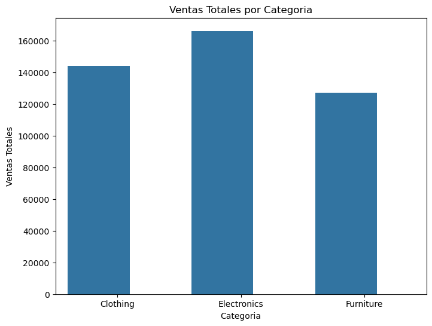

```python
#crea grafico de barras
plt.figure(figsize=(8, 6))
ventas_categoria = df_final.groupby('Category')['Amount'].sum().reset_index()
ax = sns.barplot(x='Category', y='Amount', data=ventas_categoria)

for patch in ax.patches:
    patch.set_width(0.5)  # Cambia 0.5 al ancho deseado

plt.title('Ventas Totales por Categoria')
plt.xlabel('Categoria')
plt.ylabel('Ventas Totales')
plt.show()
```

Validamos que la categoria que mas ventas($) genera es la de electronicos, seguido por ropa y por último muebles.

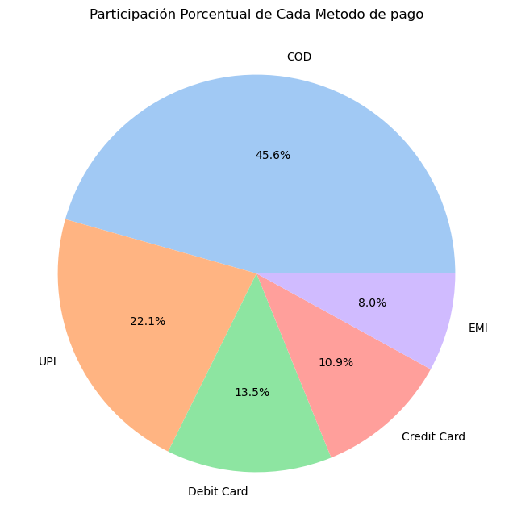

```python
# Crear gráfico de pastel
plt.figure(figsize=(8, 8))
plt.pie(df_final['PaymentMode'].value_counts(),
        labels=df_final['PaymentMode'].value_counts().index, autopct='%1.1f%%', colors=sns.color_palette('pastel'))
plt.title('Participación Porcentual de Cada Metodo de pago')
plt.show()
```

Se puede concluir que el método de pago mas utilizado es COD.

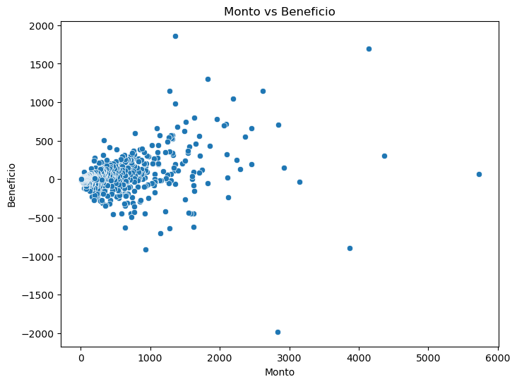

```python
#Grafico dispersion
plt.figure(figsize=(8, 6))
sns.scatterplot(x='Amount', y='Profit', data=df_final)
plt.title('Monto vs Beneficio')
plt.xlabel('Monto')
plt.ylabel('Beneficio')
plt.show()
```

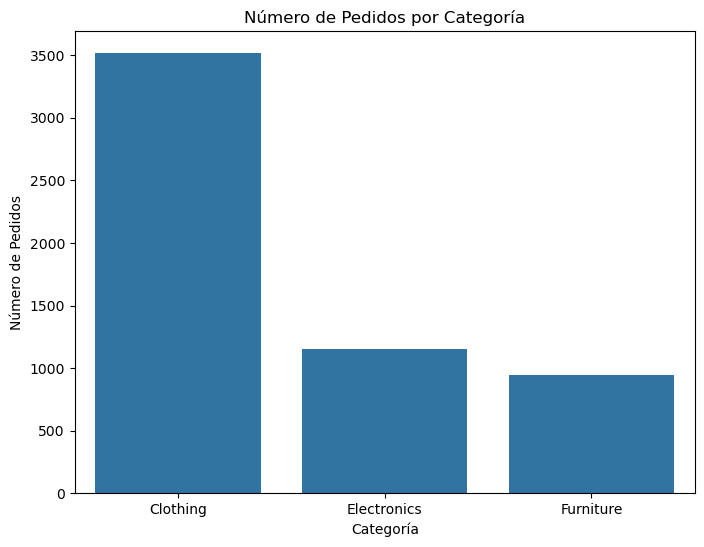

```python
#crea grafico de barras
plt.figure(figsize=(8, 6))
cantidad_productos_categoria = df_final.groupby('Category')['Quantity'].sum().reset_index()
sns.barplot(x='Category', y='Quantity', data=cantidad_productos_categoria)
plt.title('Número de Pedidos por Categoría')
plt.xlabel('Categoría')
plt.ylabel('Número de Pedidos')
plt.show()
```

La categoria que mas cantidad de productos vende es ropa, seguido de electronicos y por ultimo muebles.

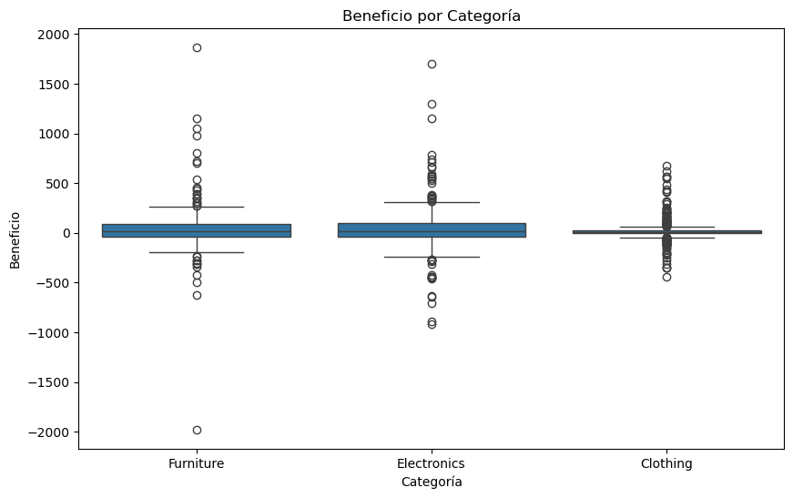

```python
#Grafico de cajas
plt.figure(figsize=(10, 6))
sns.boxplot(x='Category', y='Profit', data=df_final)
plt.title('Beneficio por Categoría')
plt.xlabel('Categoría')
plt.ylabel('Beneficio')
plt.show()
```

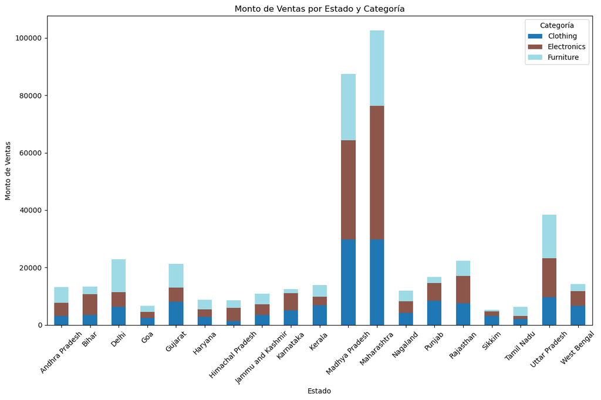

```python
# obtiene el monto de ventas por estado y categoría
ventas_por_estado_categoria = df_final.groupby(['State', 'Category'])['Amount'].sum().unstack()

# Crear el gráfico de barras apiladas
ventas_por_estado_categoria.plot(kind='bar', stacked=True, figsize=(12, 8), colormap='tab20')

plt.title('Monto de Ventas por Estado y Categoría')
plt.xlabel('Estado')
plt.ylabel('Monto de Ventas')
plt.legend(title='Categoría')
plt.xticks(rotation=45)
plt.tight_layout()
plt.show()
```

Se identifica que el estado que mas ventas($) genera es Maharashtra seguido de Madhya Pradesh. Así mismo, se muestra la distribución de las categorias vendidas por cada estado.

Se puede concluir que:

- La categoria que mas ventas genera es Electronicos.
- El metodo de pago mas utilizado es COD.
- La categoria que mas cantidad de productos vende es ropa.
- El estado donde se genera mayores ventas($) es Maharashtra